# Project 2

### Scientific Question: What are the sequential and structral differences between human Tau protein and its evolutionary closest relative?

The tau proteins are a group of six highly soluble protein isoforms produced by alternative splicing from the gene MAPT (microtubule-associated protein tau). They have roles primarily in stabilizing the internal microtubules in axons and are abundant in the neurons of the central nervous system (CNS). Tau dysfunction has been identified in multiple different brain diseases like Alzheimer's and Parkinson's Disease. The modified tau proteins form neurofibrillary tangles in the brain of AD patients. (Ellison, 2021) In Alzheimer's disease, the neuronal cytoskeleton in the brain is progressively disrupted and replaced by tangles of paired helical filaments (PHF) and straight filaments, mainly composed of hyperphosphorylated forms of TAU (PHF-TAU or AD P-TAU).

The two primary cardinal lesions associated with Alzheimer's disease are the neurofibrillary tangle and the amyloid plaque. The neurofibrillary tangle consists of abnormal accumulations of abnormally phosphorylated Tau protein. The amyloid plaque consists of a central core of beta-amyloid, surrounded by abnormally configured neuronal processes or neurites. (Perl, 2010) Squirrel monkeys, vervets, lemurs, apes, other nonhuman primates, and even dogs develop copious amyloid plaques as they age. However, most of the animals are spared of the neurofibrillary tangles formed by Tau. The previous study has shown a co-presence of PHFs and Aβ-amyloidosis in Chimpanzees. (Rosen et al., 2008) Another study has found abnormally phosphorylated tau protein in sheep and goat brains. (Braak et al., 1994) Based on these studies, I'm particularly interested in the relationship between the susceptibility to Alzheimer's disease, especially neurofibrillary tangle formation, and the structure of Tau protein.

In my project, I will investigate the tau protein of ten species and compare them to human Tau protein. These ten species are Rat(RAT), Mouse(MOUSE), Rhesus macaque(MACMU), Chimpanzee(PANTR), Western lowland gorilla(GORGO), White-handed gibbon(HYLLA), dog(CANLF), goat(CAPHI), sheep(SHEEP), and Bornean orangutan(PONPY). After conducting multiple sequence alignment, homology modeling will be used to compare the structure of human tau protein and its closest relative.

Tau protein from these ten species can be obtained from the Uniprot database. (https://www.uniprot.org/uniprot/?query=MAPt&sort=score)

"UniProt is a freely accessible database of protein sequence and functional information, many entries being derived from genome sequencing projects. It contains a large amount of information about the biological function of proteins derived from the research literature." (Wikipedia) The protein structure of healthy human tau protein and unhealthy human tau protein can be obtained from the Protein Data Bank(PDB).https://www.rcsb.org/

"Protein Data Bank (PDB) is the single worldwide archive of structural data of biological macromolecules. It includes data obtained by X-ray crystallography and nuclear magnetic resonance (NMR) spectrometry submitted by biologists and biochemists from all over the world." (ScienceDirect)

### Scientific Hypothesis: If there are differences in susceptibility to Alzheimer's diseases between human and other animals, then there is likely to be a specific structral difference between other tau proteins and human tau protein.

I searched for the gene coding the tau protein, MAPT, on UniProt and downloaded the 11 sequences from different species as a fasta file.

This fasta file is then read in here for multiple sequence alignment, the first bioinformatics analysis. The result of the multiple sequence alignment is saved as a second fasta file.

This fasta file is then parsed and displayed through Biopython, a phylogenetic tree is also created based on the multiple sequence alignment to visualize the evolutionary relationship between these 11 proteins. The second bioinformatics analysis done is phylogenetic tree.

The third bioinformatics analysis is homology modeling. The homology modeling is done using healthy and unhealthy human tau protein as templates, creating Chimpanzee tau protein structure.

These structures are then imported into pymol and compared.

The data that I used for MSA was downloaded from UniProt. I searched for the gene coding for the Tau protein, MAPT, on UniProt and downloaded the 11 sequences of my choice as a single fasta file.

The template structure that I used for homology modeling was downloaded from the Protein Data Bank (PDB). I searched Tau protein on PDB and found one healthy structure of human Tau protein binding to microtubules and one unhealthy human Tau protein, which is in its paired helical form found in the brain of Alzheimer's patient. These two structures are then downloaded as PDB files.

### Loading in packages

Biopython: Biopython is an open-source collection of non-commercial Python tools for computational biology and bioinformatic. It is the largest and most popular bioinformatics package for Python. It contains classes to represent biological sequences and sequence annotations, and it is able to read and write to a variety of file formats. Biopython provides functions to deal with DNA, RNA & protein sequence operations. It also provides lot of parsers to read all major genetic databases like GenBank, SwissPort, FASTA. Here it is used to perform multiple seqence alignment, generate phylogenetic tree, and display the results. (https://biopython.org/docs/1.76/api/Bio.html)

Argtable: Argtable is an ANSI C library for parsing GNU style command line options. It enables a program's command line syntax to be defined in the source code as an array of argtable structs. The command line is then parsed according to that specification and the resulting values are returned in those same structs where they are accessible to the main program. Both tagged (-v, --verbose, --foo=bar) and untagged arguments are supported, as are multiple instances of each argument. (Reference: http://argtable.sourceforge.net/) Here, it is a required package in order to use the Clustal Omega command line.

Clustal Omega: Clustal Omega is a package for making multiple sequence alignments (MSAs). In general, Clustal Omega is fast enough to make very large alignments and the accuracy of protein alignments is high when compared to alternative packages. (Sievers, 2017) It uses seeded guide trees and HMM profile-profile techniques to generate alignments between three or more sequences. It produces biologically meaningful multiple sequence alignments of divergent sequences. After conducting MSA with clustal omega, we can use it to see the evolutionary relationships of sequences via viewing Cladograms or Phylograms. (http://www.clustal.org/omega/)

IPython: IPython is an interactive shell that is built with python. It provides a more useful shell environment to execute python code in REPL (Read Eval Print Loop). It makes it more interactive by adding features like syntax highlighting, code completion etc. Here I use the IPython package to embed youtube videos in my script. (https://ipython.readthedocs.io/en/stable/)

IPython doesn't require installation.

```python
#install biopython
pip install Bio
```

```
     |████████████████████████████████| 271 kB 6.5 MB/s eta 0:00:01
```

```python
# install argtable2
conda install -c etetoolkit argtable2
```

[output not shown]

```python
# install clustal omega
conda install -c bioconda clustalo
```

[output not shown]

```python
from Bio import AlignIO, SeqIO, Phylo
from Bio.Align.Applications import ClustalOmegaCommandline
from IPython.display import YouTubeVideo
```

### Part 1: Performing Bioinformatics Analysis

### Part 2: Plotting the results

### Part 1A: Multiple Sequence alignment

A FASTA file is a text file. Each sequence begins with a single-line description, followed by lines of sequence data. The single-line description contains a greater-than (>) symbol in the first column, followed by the sequence name.

Multiple sequence alignment(MSA) refers to the sequence alignment of three or more biological sequences, in this case protein sequence. Here, MSA is performed through clustal omega, using the fasta file downloaded from Uniprot which contains the 11 unaligned sequences. The aligned sequences of the 11 tau proteins are stored in a fasta file.

```python
# Write the multiple sequence alignment as a function

# Create a function called COalign
# Takes in three parameters
# filein is the file name containing the sequences to be aligned
# fileout is the file name and type where the function will store the output(aligned sequences)
# gtout is the file name and type where the function will store the guide tree output file
# the guide tree file will later be used to generate phylogenetic tree
def COalign(filein, fileout, gtout):

    # Use Clustal Omega Command line function to perform multiple sequence alignment
    # Define local variable CO_cline, which later becomes a function that can be called
    CO_cline = ClustalOmegaCommandline(infile = filein, # passing the parameter filein into the function

                                       # passing fileout into the function
                                      outfile = fileout,

                                       # this line will force file overwrite
                                       #pretending errors from running the function multiple times
                                      force = True,

                                       # this line tells clustal omega to use
                                       # full distance matrix for guide-tree calculation
                                      distmat_full = True,

                                       # passing gtout into the function
                                      guidetree_out = gtout,

                                       # tell clustal omega to store the output as fasta file format
                                      outfmt = 'fasta')

    # perform MSA based on the settings we passed into the function
    CO_cline()

    # visualize the alignment by using the read function in AlignIO package
    # Define local variable align, which contains the result of MSA
    align = AlignIO.read(fileout, 'fasta')

    # Return the printout sequences
    return print(align)
```

```python
# Call the COalign function to perform MSA and visualize the aligned sequences
COalign('Data/Tau_unaligned.fasta', 'Data/Tau_aligned.fasta', 'Data/Tau_aligned.dnd')
```

```
Alignment with 11 rows and 817 columns
MAEPRQEFEVMEDHAGTYGLGDRKDQGGYTMHQDQEGDTDAGLK...QGL sp|P10636|TAU_HUMAN
MAEPRQEFDTMEDQA-----------GDYTMLQDQEGDMDHGLK...QGL sp|P19332|TAU_RAT
MADPRQEFDTMEDHA-----------GDYTLLQDQEGDMDHGLK...QGL sp|P10637|TAU_MOUSE
MAEPRQEFDVMEDHAGTYGLGDRKDQEGYTMLQDQEGDTDAGLK...QGL sp|P57786|TAU_MACMU
MAEPRQEFEVMEDHAGTYGLGDRKDQGGYTMHQDQEGDTDAGLK...QGL sp|Q5YCW1|TAU_PANTR
MAEPRQEFEVMEDHAGTYGLGDRKDQGGYTMLQDQEGDTDAGLK...QGL sp|Q5YCW0|TAU_GORGO
MAEPRQEFDVMEDHAGTYGLGDRKDQGGYTMLQDQEGDTDAGLK...QGL sp|Q5YCV9|TAU_HYLLA
MAEPHQEFDVTEDHAGTYGLGDRKDQGGYTMLQDQEGDTDAGLK...QGL sp|Q5S6V2|TAU_PONPY
MAEPRQEFTVMEDHAGTYGKD-LPSQGGYTLLQDHEGDVDHGLK...QGL tr|E2R3H9|E2R3H9_CANLF
MAEPRQEFDVMEDHAQ----------GDY-TLQDHEGDMEPGLK...QGL sp|O02828|TAU_CAPHI
MAEPRQEFDVMEDHAQ----------GDY-TLQDHEGDMEPGLK...QGL tr|W5PNU3|W5PNU3_SHEEP
```

### Part 2A: Phylogenetic tree (Plotting the result of multiple sequence alignment)

```python
# Use Phylo.read to generate Phylogenetic tree
# Read in the guide tree output file from MSA, the file type is newick tree file
# Define global variable tree, containing the parsed guide tree file
tree = Phylo.read("Data/Tau_aligned.dnd", "newick")

#The function draw_ascii creates a simple ASCII-art (plain text) dendrogram.
# It takes in the parsed guide tree file and generate a phylogenetic tree based on that
Phylo.draw_ascii(tree)
```

```
  ___________________________________________________ tr|W5PNU3|W5PNU3_SHEEP
_|           _________________________________________ tr|E2R3H9|E2R3H9_CANLF
 |          |
 |__________|                         _______________ sp|P19332|TAU_RAT
            |  ______________________|
            | |                      |_______________ sp|P10637|TAU_MOUSE
            |_|
              |    __________________________________ sp|O02828|TAU_CAPHI
              |   |
              |___|          ________________________ sp|Q5S6V2|TAU_PONPY
                  |         |
                  |_________|               _________ sp|P10636|TAU_HUMAN
                            |      ________|
                            |     |        |_________ sp|Q5YCW1|TAU_PANTR
                            |_____|
                                 ____________________ sp|Q5YCV9|TAU_HYLLA
                                | |
                                |           _________ sp|P57786|TAU_MACMU
                                |__________|
                                           |_________ sp|Q5YCW0|TAU_GORGO
```

### Part 1B & 2B: Homology modeling

Homology modeling, also known as comparative modeling of protein, refers to constructing an atomic-resolution model of the "target" protein from its amino acid sequence and an experimental three-dimensional structure of a related homologous protein (the "template"). (Wikipedia)

In my project, I will use SWISS-model, which is a fully automated protein structure homology-modeling server. (https://swissmodel.expasy.org/) On this website, I will use the User-template input type (https://swissmodel.expasy.org/interactive#structure), which takes in a target sequence in either plain string or fasta file type, and a template file, which is a pdb file downloaded from the Protein Data Bank. Then the website will generate a homology model for my target sequence, along with the Qmean Z score plot, and local quality estimate (Explanation in following sections).

I found a NMR structure of human Tau protein, showing the structure of it when it is bound to microtubules. I used this structure as a template, and the TAU_PANTR sequence from UniProt as the target sequence to generate a homology model of the normal chimpanzee tau protein.

The diseased template that I chose is a cryo-EM structure of the paired helical filament from AD brain. I used this as a template and the TAU_PANTR sequence as the target sequence.

#### Explanation of the output from homology modeling

- Local Quality Estimate shows the expected similarity to the native structure (y axis) for each residue of the model (x axis). The bars above the line indicate relaticely good estimate for the target structure while the bars below the line indicate low quality estimate. The blue color indicates high confidence gradient and the orange color represents low confidence gradient.
- GMQE gives an overall model quality measurement between 0 and 1, with higher numbers indicating higher expected quality.
- The QMEAN Z score shows how many SD from the mean is my model score given a score distribution from a large set of experimentally determined structures. Z-scores around 0.0 therefore reflect a "native-like" structure.
- The QMEAN Z score of the model in comparison with non-redundant set of PDB Structures is shown in a dot plot. The x-axis shows protein length (number of residues). The y-axis is the "QMEAN" score. Every dot represents one experimental protein structure. Black dots are experimental structures with a "QMEAN" score within 1 standard devation of the mean (|Z-score| between 0 and 1), experimental structures with a |Z-score| between 1 and 2 are grey. Experimental structure that are even further from the mean are light grey. The target model is represented as a red star.

This is the result of PANTR_healthy homology modeling.

The sequence identity between the target and the template is 100%. The Global Model Quality Estimate(GMQE) score for the target model is 0.65. The QMEAN Z score is -4.96. These scores show that PANTR_healthy model is of low quality and might not be able to represent the nature structure accurately.

Here we can see from the Local Quality Estimate that the overall quality of the estimate is not good for the chimpanzee tau protein. Most of the residues predicted are in the orange color with a mean of 0.53. Generally, this score indicates that the homology model is of low quality.

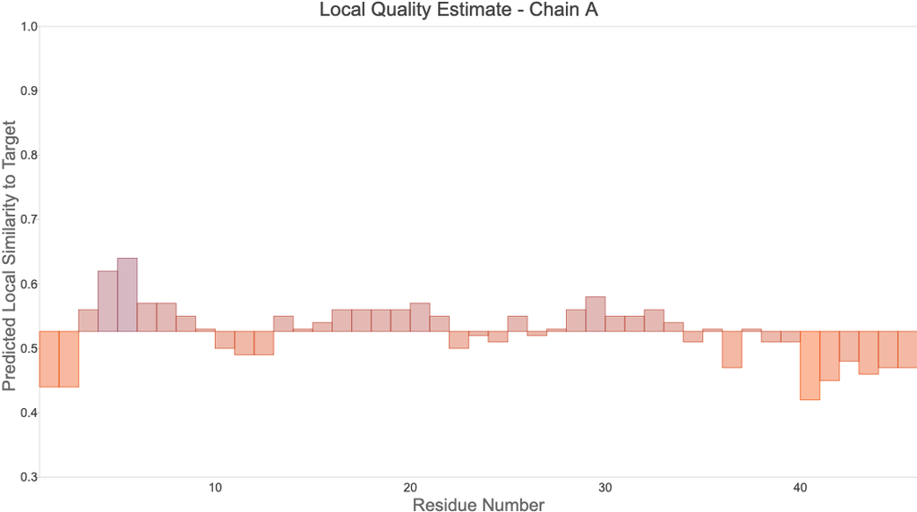

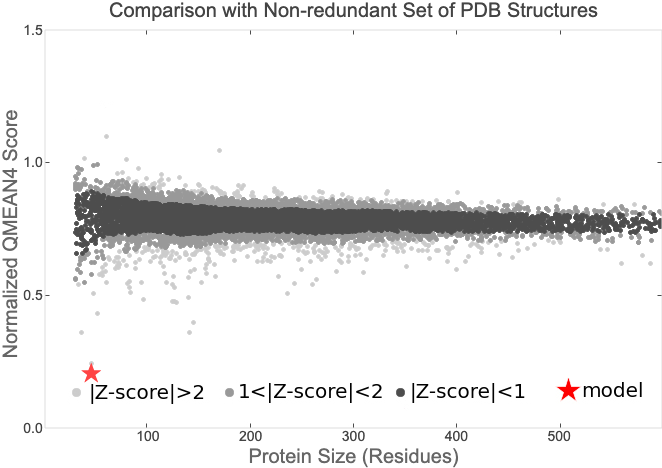

```python
# Embed the Youtube video for comparing the homology model of PANTR_healthy and the healthy human Tau protein
YouTubeVideo('UPuwAFlsZBw', width = 800, height = 500)
```

[video not shown]

This is the result of PANTR_diseased homology modeling.

The sequence identity between the target and the template sequence is 51.32%. The GMQE score for the diseased model is 0.03. The QMEAN Z score is -4.44. These scores indicate that the homology model for the diseased chimpanzee tau protein is of low quality.

The local quality estimate of the PANTR_diseased homology model has a mean of 0.42, which also indicates the low quality of homology modeling. However, compared to the PANTR_healthy model, part of the residue of PANTR_diseased show slightly higher confidence gradient (in light blue), indicating that part of the chain produced might be close to the real structure.

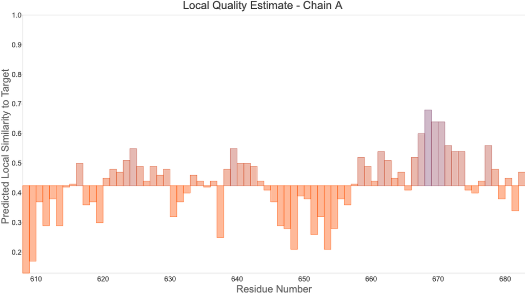

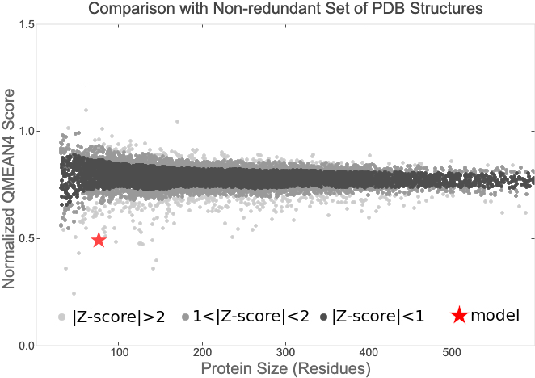

```python
# Embed the Youtube video for comparing the homology model of PANTR_diseased and the diseased human Tau protein
YouTubeVideo('og_aySZk-l8', width = 800, height = 500)
```

[video not shown]

### Analyzing the Results (15 points)

The phylogenetic tree based on the multiple sequence alignment between the 11 tau protein sequences shows that TAU_PANTR (chimpanzee) is the closest relative of TAU_HUMAN. This result aligns with previous studies since chimpanzee is the only species that develop neurofibrillary tangle naturally. We can also see that the human tau protein sequence is very similar compared to other primate species, indicating that these primate species may also exhibit some similar tau protein pathology compared to human.

To see the structural differences between chimpanzee tau protein and human tau protein, homology modeling using the healthy human tau protein and the diseased human tau protein as templates are then conducted. Results show that PANTR_healthy is a fairly low quality model. Current models of the human tau protein are usually showing the structure of the tau protein bound to microtubules, making the length of the tau protein shown very short. This short length of human tau protein may contribute to the low quality of PANTR_healthy. Another reason can be the chimpanzee tau protein sequence has no difference compared with the human tau protein template in terms of amino acid sequence, making homology modeling hard to conduct. This high similarity is shown in the homology modeling result. With a sequence identity of 100%, the two protein structures look very similar in Pymol. In the movie, the blue structure is PANTR_healthy generated from homology modeling. When we align the template human tau protein with PANTR_healthy, we can see that the primary structures of these two proteins are exactly the same. The main differences between the two structures are the secondary structures. I showed three secondary structure differences in the movie, all of them are beta sheets. Based on this comparison, I think it is likely that chimpanzee and human tau protein have similar properties in their normal conformation. The differences in secondary structure may contribute to their different abilities to form neurofibrillary tangles.

The homology modeling for diseased chimpanzee tau protein is conducted using a paired helical filament(PHF) in human AD brain as template. The result of homology modeling shows that the PANTR_diseased is also a low quality model. This is expected since the formation of neurofibrillary tangles is due to hyperphosphorylation of the tau protein, which changes its sequence and conformation. In pymol, the blue structure is PANTR_diseased and the pink structure is PHF in human AD brain. There are multiple differences between these two structures. Most of them are secondary structural differences. I think this might due to the low quality homology modeling of PANTR_diseased, which shows few secondary structures for the target protein. Besides the secondary structure differences, there is a loop difference presented. This loop difference may contribute to the different aggregation properties of chimpanzee tau protein and human tau protein.